# Ref/Stress Bug Sites Wide Filter in the Coastal EcoRegions

Jason Hill

2021-04-16

# Overview

This script was built using R 4.0.2 (Taking Off Again).

This tool filters reference and stress sites from Virginia and West Virginia EDAS databases, in this script we cast a “wide net” net on all the data (n=5292). This initial filter looks at 6 stress parameters that were available for the most sites in the database(s).

This is just step one of two step process, VDEQ and WVDEP biologists will review the results and help refine the reference and stress sites based on their site specific knowledge. WV DEP data was collected between 1999-2017, VDEQ data collections occurred from 2008-2020, but the majority was collected between 2012-2019.

Below is a breakdown of the sites that were available:

```
+ Total Sites Filtered = 5,292
+ VDEQ Sites = 3,279
+ WVDEP Sites = 2,013
+ Coastal Bioregion = 334
+ Piedmont Bioregion = 1,723
+ Mountain = 3,235
```

This script specifically looks at the Coastal Bioregions (n=334), the reference and stress parameters have been altered to match the criteria used in the 2013 publication of “The Virginia Coastal Plain Macroinvertebrate Index” reflected in the two following lists:

Least Disturbed (Ref) Filter Parameters:

1. DO > 4 mg/L
2. pH > 6, < 9
3. Sp Cond < 200 uS/cm
4. TN <= 1.5 mg/L
5. TP <= 0.05 mg/L
6. Total Habitat > 140

Sites are assigned R1, R2, R3, or R4 based on the number parameters the site meets.

- R1 = Great meets all ref criteria (6)
- R2 = Good meets most and of the ref criteria (5)
- R3 = OK meets (4) ref criteria
- R4 = Sites with very few ref conditions (1-3)

Stress Filters Parameters

Sites are assigned S1, S2, or S3 based on the number parameters the site meets.

- S1 = Most disturbed sites, exceeded multiple stress filters (3+)
- S2 = Moderately stress sites, exceeded one or two stress filters (1-2)
- S3 = Counts sites with 0 Stress Parameters

# Results

The first step of the process is to load all the sites and stress parameters into R. You can look at the first few rows below, note their are 17 columns at this point in the process. Note the number of sites is much less as only sites in the coast plains bioregion have been filtered

| DataSource | UID | StationID | Year | LatitudeDD | LongitudeDD | Basin | SubBasin | EcoRegion | BioRegion | AREA_SQ_MILES | DO | pH | SpCond | TN | TP | TotHab |
| --- | --- | --- | --- | --- | --- | --- | --- | --- | --- | --- | --- | --- | --- | --- | --- | --- |
| VDEQ_BUG | 1ACON002.88 | 1ACON002.88 | 38037 | 37.91752 | -76.51106 | Potomac | Potomac | Southeastern Plains | Coast |  | 8.689 | 7.157 | 117.82 | 0.685 | 0.1 | 87 |
| VDEQ_BUG | 5BXAT000.30 | 5BXAT000.30 | 39947 | 36.57461 | -76.0938 | Chowan | Chowan | Middle Atlantic Coastal Plain | Coast |  | 1 | 6.4 | 796 | 1.34 | 0.365 | 127 |
| VDEQ_BUG | 2-BEV002.00 | 2-BEV002.00 | 39960 | 37.59333 | -77.3588 | James | James | Southeastern Plains | Coast |  | 6.6 | 6.6 | 99 | 1.68 | 0.03 | 144 |
| VDEQ_BUG | 8-AYL002.27 | 8-AYL002.27 | 39960 | 37.77964 | -77.10206 | York | York | Southeastern Plains | Coast |  | 5.6 | 5.9 | 65 | 0.82 | 0.02 | 164 |
| VDEQ_BUG | 2-WRD005.40 | 2-WRD005.40 | 39967 | 37.21576 | -77.08154 | James | James | Southeastern Plains | Coast |  | 7.1 | 6.6 | 95 | 0.37 | 0.04 | 141 |
| VDEQ_BUG | 5AMRN000.38 | 5AMRN000.38 | 39967 | 36.76992 | -77.09432 | Chowan | Chowan | Southeastern Plains | Coast |  | 3.8 | 6.1 | 104 | 1.13 | 0.02 | 130 |
| VDEQ_BUG | 3-CAT011.62 | 3-CAT011.62 | 39973 | 38.03992 | -76.82734 | Rappahannock | Rappahannock | Southeastern Plains | Coast |  | 6.4 | 5.5 | 48 | 0.85 | 0.05 | 155 |
| VDEQ_BUG | 7-CMS002.00 | 7-CMS002.00 | 39973 | 37.89959 | -76.46617 | Chesapeake Bay | Chesapeake Bay | Southeastern Plains | Coast |  | 4.8 | 5.7 | 78 | 0.73 | 0.105 | 130 |
| VDEQ_BUG | 2-JMS115.29 | 2-JMS115.29 | 40001 | 37.5494444444444 | -77.5119444444444 | James | James | Southeastern Plains | Coast |  | 9.5 | 8.5 | 165 | 0.44 | 0.03 | 155 |
| VDEQ_BUG | 2-JMS115.29 | 2-JMS115.29 | 40074 | 37.5494444444444 | -77.5119444444444 | James | James | Southeastern Plains | Coast |  | 10.5 | 8.6 | 284 | 0.44 | 0.03 | 170 |

[output cut: 324 more lines]

| DataSource | UID | StationID | Year | LatitudeDD | LongitudeDD | Basin | SubBasin | EcoRegion | BioRegion | AREA_SQ_MILES | DO | pH | SpCond | TN | TP | TotHab | TotHabStress | TNStress | TPStress | DOStress | PHStress | SpCondStress | CountStress | CountRef | CountFair | CountFilterParms | StressLevel | RefLevel | S1 | … |
| --- | --- | --- | --- | --- | --- | --- | --- | --- | --- | --- | --- | --- | --- | --- | --- | --- | --- | --- | --- | --- | --- | --- | --- | --- | --- | --- | --- | --- | --- | --- |
| VDEQ_BUG | 1ACON002.88 | 1ACON002.88 | 38037 | 37.91752 | -76.51106 | Potomac | Potomac | Southeastern Plains | Coast |  | 8.689 | 7.157 | 117.82 | 0.685 | 0.1 | 87 | Stress | Ref | Fair | Ref | Ref | Ref | 1 | 4 | 1 | 6 | S2 | R3 | 0 | … |
| VDEQ_BUG | 5BXAT000.30 | 5BXAT000.30 | 39947 | 36.57461 | -76.0938 | Chowan | Chowan | Middle Atlantic Coastal Plain | Coast |  | 1 | 6.4 | 796 | 1.34 | 0.365 | 127 | Fair | Ref | Stress | Stress | Ref | Stress | 3 | 2 | 1 | 6 | S1 | R4 | 1 | … |
| VDEQ_BUG | 2-BEV002.00 | 2-BEV002.00 | 39960 | 37.59333 | -77.3588 | James | James | Southeastern Plains | Coast |  | 6.6 | 6.6 | 99 | 1.68 | 0.03 | 144 | Ref | Fair | Ref | Ref | Ref | Ref | 0 | 5 | 1 | 6 | S3 | R2 | 0 | … |
| VDEQ_BUG | 8-AYL002.27 | 8-AYL002.27 | 39960 | 37.77964 | -77.10206 | York | York | Southeastern Plains | Coast |  | 5.6 | 5.9 | 65 | 0.82 | 0.02 | 164 | Ref | Ref | Ref | Ref | Fair | Ref | 0 | 5 | 1 | 6 | S3 | R2 | 0 | … |
| VDEQ_BUG | 2-WRD005.40 | 2-WRD005.40 | 39967 | 37.21576 | -77.08154 | James | James | Southeastern Plains | Coast |  | 7.1 | 6.6 | 95 | 0.37 | 0.04 | 141 | Ref | Ref | Ref | Ref | Ref | Ref | 0 | 6 | 0 | 6 | S3 | R1 | 0 | … |
| VDEQ_BUG | 5AMRN000.38 | 5AMRN000.38 | 39967 | 36.76992 | -77.09432 | Chowan | Chowan | Southeastern Plains | Coast |  | 3.8 | 6.1 | 104 | 1.13 | 0.02 | 130 | Fair | Ref | Ref | Stress | Ref | Ref | 1 | 4 | 1 | 6 | S2 | R3 | 0 | … |
| VDEQ_BUG | 3-CAT011.62 | 3-CAT011.62 | 39973 | 38.03992 | -76.82734 | Rappahannock | Rappahannock | Southeastern Plains | Coast |  | 6.4 | 5.5 | 48 | 0.85 | 0.05 | 155 | Ref | Ref | Ref | Ref | Fair | Ref | 0 | 5 | 1 | 6 | S3 | R2 | 0 | … |
| VDEQ_BUG | 7-CMS002.00 | 7-CMS002.00 | 39973 | 37.89959 | -76.46617 | Chesapeake Bay | Chesapeake Bay | Southeastern Plains | Coast |  | 4.8 | 5.7 | 78 | 0.73 | 0.105 | 130 | Fair | Ref | Stress | Ref | Fair | Ref | 1 | 3 | 2 | 6 | S2 | R4 | 0 | … |
| VDEQ_BUG | 2-JMS115.29 | 2-JMS115.29 | 40001 | 37.5494444444444 | -77.5119444444444 | James | James | Southeastern Plains | Coast |  | 9.5 | 8.5 | 165 | 0.44 | 0.03 | 155 | Ref | Ref | Ref | Ref | Ref | Ref | 0 | 6 | 0 | 6 | S3 | R1 | 0 | … |
| VDEQ_BUG | 2-JMS115.29 | 2-JMS115.29 | 40074 | 37.5494444444444 | -77.5119444444444 | James | James | Southeastern Plains | Coast |  | 10.5 | 8.6 | 284 | 0.44 | 0.03 | 170 | Ref | Ref | Ref | Ref | Ref | Fair | 0 | 5 | 1 | 6 | S3 | R2 | 0 | … |

[output cut: 324 more lines]

The next step of the process is to combine the reference and stress count together to find the sites with the highest stress and least stress. As an example, I combine sites with 3 stress or more (S1 sites) and sites with 1-3 reference filter (R4 sites). By adding sites that are S1 and R4, I am looking for sites that have a lot of disturbance and very few reference like qualities. These sites are then labeled “Highest Stress”. By combining sites with no stress S3 and sites the meet all reference filters R1, I find the sites with the least disturbance, they are assigned “BestRef”. I repeat combinations of the reference and stress results until all sites receive one of the eight categories. You can see that we now have 61 columns in the table.

| DataSource | UID | StationID | Year | LatitudeDD | LongitudeDD | Basin | SubBasin | EcoRegion | BioRegion | AREA_SQ_MILES | DO | pH | SpCond | TN | TP | TotHab | TotHabStress | TNStress | TPStress | DOStress | PHStress | SpCondStress | CountStress | CountRef | CountFair | CountFilterParms | StressLevel | RefLevel | S1 | … |
| --- | --- | --- | --- | --- | --- | --- | --- | --- | --- | --- | --- | --- | --- | --- | --- | --- | --- | --- | --- | --- | --- | --- | --- | --- | --- | --- | --- | --- | --- | --- |
| VDEQ_BUG | 1ACON002.88 | 1ACON002.88 | 38037 | 37.91752 | -76.51106 | Potomac | Potomac | Southeastern Plains | Coast |  | 8.689 | 7.157 | 117.82 | 0.685 | 0.1 | 87 | Stress | Ref | Fair | Ref | Ref | Ref | 1 | 4 | 1 | 6 | S2 | R3 | 0 | … |
| VDEQ_BUG | 5BXAT000.30 | 5BXAT000.30 | 39947 | 36.57461 | -76.0938 | Chowan | Chowan | Middle Atlantic Coastal Plain | Coast |  | 1 | 6.4 | 796 | 1.34 | 0.365 | 127 | Fair | Ref | Stress | Stress | Ref | Stress | 3 | 2 | 1 | 6 | S1 | R4 | 1 | … |
| VDEQ_BUG | 2-BEV002.00 | 2-BEV002.00 | 39960 | 37.59333 | -77.3588 | James | James | Southeastern Plains | Coast |  | 6.6 | 6.6 | 99 | 1.68 | 0.03 | 144 | Ref | Fair | Ref | Ref | Ref | Ref | 0 | 5 | 1 | 6 | S3 | R2 | 0 | … |
| VDEQ_BUG | 8-AYL002.27 | 8-AYL002.27 | 39960 | 37.77964 | -77.10206 | York | York | Southeastern Plains | Coast |  | 5.6 | 5.9 | 65 | 0.82 | 0.02 | 164 | Ref | Ref | Ref | Ref | Fair | Ref | 0 | 5 | 1 | 6 | S3 | R2 | 0 | … |
| VDEQ_BUG | 2-WRD005.40 | 2-WRD005.40 | 39967 | 37.21576 | -77.08154 | James | James | Southeastern Plains | Coast |  | 7.1 | 6.6 | 95 | 0.37 | 0.04 | 141 | Ref | Ref | Ref | Ref | Ref | Ref | 0 | 6 | 0 | 6 | S3 | R1 | 0 | … |
| VDEQ_BUG | 5AMRN000.38 | 5AMRN000.38 | 39967 | 36.76992 | -77.09432 | Chowan | Chowan | Southeastern Plains | Coast |  | 3.8 | 6.1 | 104 | 1.13 | 0.02 | 130 | Fair | Ref | Ref | Stress | Ref | Ref | 1 | 4 | 1 | 6 | S2 | R3 | 0 | … |
| VDEQ_BUG | 3-CAT011.62 | 3-CAT011.62 | 39973 | 38.03992 | -76.82734 | Rappahannock | Rappahannock | Southeastern Plains | Coast |  | 6.4 | 5.5 | 48 | 0.85 | 0.05 | 155 | Ref | Ref | Ref | Ref | Fair | Ref | 0 | 5 | 1 | 6 | S3 | R2 | 0 | … |
| VDEQ_BUG | 7-CMS002.00 | 7-CMS002.00 | 39973 | 37.89959 | -76.46617 | Chesapeake Bay | Chesapeake Bay | Southeastern Plains | Coast |  | 4.8 | 5.7 | 78 | 0.73 | 0.105 | 130 | Fair | Ref | Stress | Ref | Fair | Ref | 1 | 3 | 2 | 6 | S2 | R4 | 0 | … |
| VDEQ_BUG | 2-JMS115.29 | 2-JMS115.29 | 40001 | 37.5494444444444 | -77.5119444444444 | James | James | Southeastern Plains | Coast |  | 9.5 | 8.5 | 165 | 0.44 | 0.03 | 155 | Ref | Ref | Ref | Ref | Ref | Ref | 0 | 6 | 0 | 6 | S3 | R1 | 0 | … |
| VDEQ_BUG | 2-JMS115.29 | 2-JMS115.29 | 40074 | 37.5494444444444 | -77.5119444444444 | James | James | Southeastern Plains | Coast |  | 10.5 | 8.6 | 284 | 0.44 | 0.03 | 170 | Ref | Ref | Ref | Ref | Ref | Fair | 0 | 5 | 1 | 6 | S3 | R2 | 0 | … |

[output cut: 324 more lines]

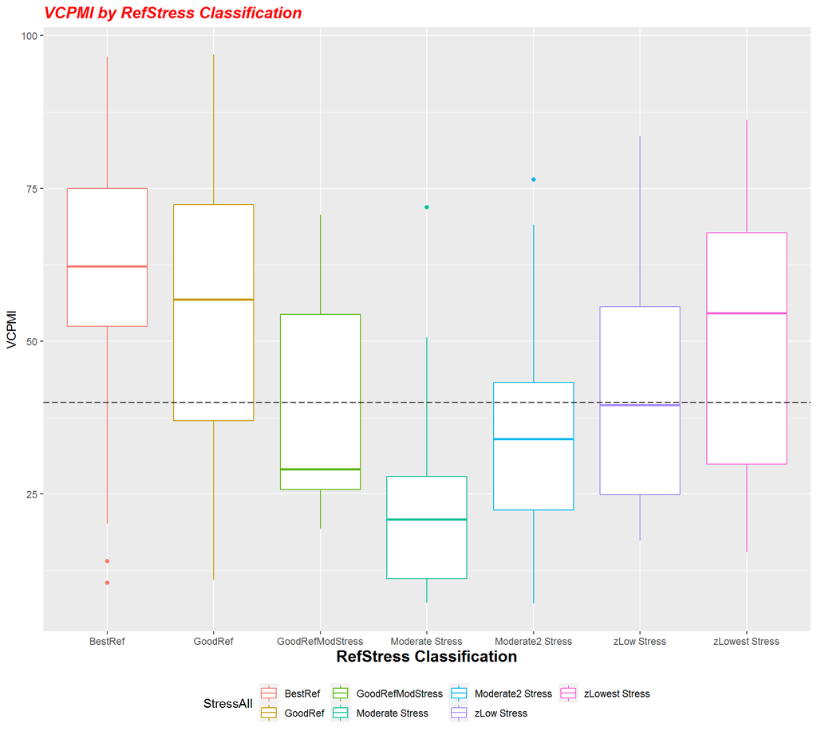

Reference and stress classification.

- Best Ref (n=59) = Best Ref Sites Count (R1 + S3) - 6 Ref Criteria Met and Zero Stressor Count
- Good Ref (n=107) = Good Ref Sites Count (R2 + S3) - 5 Ref Criteria Met and Zero Stressor Count
- GoodRefModStress (n=16) = Good Ref Sites Count (R2 + S2) - 5 Ref Criteria Met but has at least one Stressor
- Highest Stress (n=2) = Most disturbed sites, Highest Stress Count (S1 + R4) - 3+ Stressors and Low Reference Count
- Moderate Stress (n=47) = Moderately stress sites, Moderate Stress Count (S2 + R4) - 1 or 2 Stressors and Low Reference Count
- Moderate2 Stress (n=26) = Moderate2 Stress Count (S2 + R3) - 1 or 2 Stressors and Med Reference Count
- zLow Stress (n=30) = Low Stress Count (S3 + R4) - 0 Stressors but Low Reference Count
- zLowest Stress (n=47) = Lowest Stress/Weak Ref Count (S3 + R3) - 0 Stressors and 4 Reference Filters Met

The histogram below showing the final count for each category of stress.

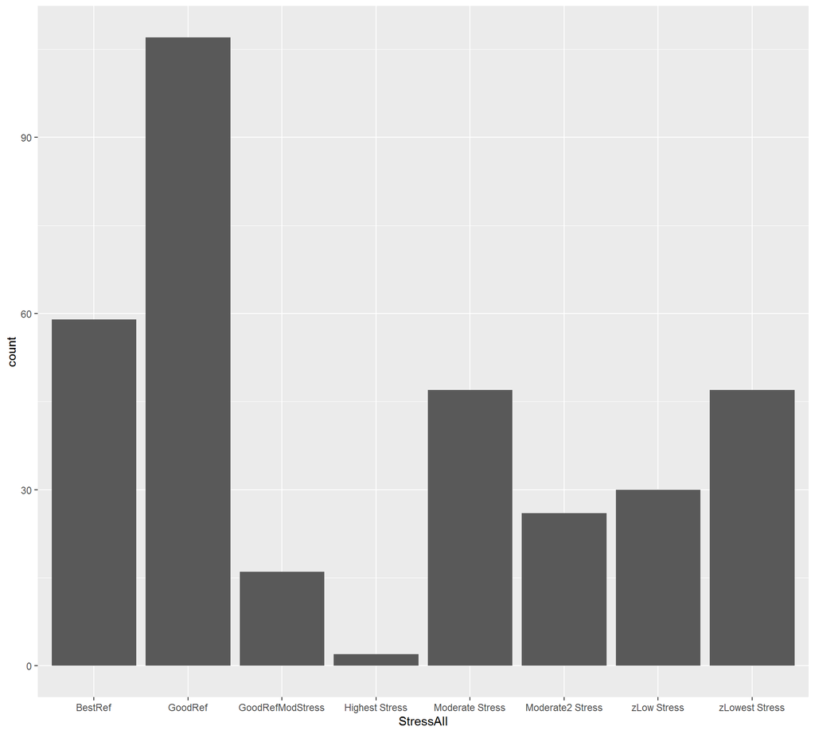

# Map of Sites by Reference and Stress Classifications

[interactive chart not shown]

# Table of Results

Below is table of reference and stress classification totals by agency, bioregion, and regional office.

| RefStressCode | nTotal | nVDEQ | nCoast | nNRO | nPRO | nTRO |
| --- | --- | --- | --- | --- | --- | --- |
| BestRef | 59 | 59 | 59 | 24 | 34 | 1 |
| GoodRef | 107 | 107 | 107 | 27 | 73 | 7 |
| GoodRefModStress | 16 | 16 | 16 | 5 | 8 | 3 |
| Highest Stress | 2 | 2 | 2 |  |  |  |
| Moderate Stress | 47 | 47 | 47 | 5 | 5 | 37 |
| Moderate2 Stress | 26 | 26 | 26 | 3 | 16 | 7 |
| zLow Stress | 30 | 30 | 30 | 1 | 9 | 20 |
| zLowest Stress | 47 | 47 | 47 | 11 | 24 | 12 |

# Table of Stress Sites By EcoRegion

Below is table of stress classification totals by ecoregions (VDEQ data only).

| EcoRegion | DOStress | TotHabStress | TPStress | TNStress | PHStress | SpCondStress |
| --- | --- | --- | --- | --- | --- | --- |
| Middle Atlantic Coastal Plain | 15 | 0 | 11 | 25 | 0 | 3 |
| Southeastern Plains | 15 | 22 | 13 | 0 | 0 | 2 |